# 30-Day Mortality Rate Induced by Malignant Neoplasm

## Introduction

MIMIC-III (Medical Information Mart for Intensive Care III) is a large, freely-available database comprising deidentified health-related data associated with over forty thousand patients who stayed in critical care units of the Beth Israel Deaconess Medical Center between 2001 and 2012.

The database includes information such as demographics, vital sign measurements made at the bedside (~1 data point per hour), laboratory test results, procedures, medications, caregiver notes, imaging reports, and mortality (both in and out of hospital).

In this project, we study how well the set of predictors, including severity of malignant neoplasm, whether malignant neoplasm was the principal diagnosis, the actual code corresponding to the diagnosis and patient’s demographic information, predict the 30-day mortality rate induced by malignant neoplasm. We will use two analytical approaches to address our goal.

## Data Preparation

Load database libraries and the tidyverse frontend:

```r
library(DBI)
library(RPostgreSQL)
library(tidyverse)
library(dplyr)
library(lubridate)
```

```r
library(ggplot2)
```

Credentials for using PostgreSQL database. We are going to use username `postgres` with password `postgres` to access the `mimic` database in the schemee `mimiciii`.

```r
# Load configuration settings
dbdriver <- 'PostgreSQL'
user  <- 'postgres'
password <- 'postgres'
dbname <- 'mimic'
schema <- 'mimiciii'
# Connect to the database using the configuration settings
con <- dbConnect(RPostgreSQL::PostgreSQL(),
                 dbname = dbname,
                 #host = host,
                 #port = port,
                 user = user,
                 password = password)
# Set the default schema
dbExecute(con, paste("SET search_path TO ", schema, sep=" "))
```

First, we want to restrict to patients who had malignant neoplasm. We search for string `malignant neoplasm` in the `long_title` of table `d_icd_diagnoses`:

```r
tbl(con, "d_icd_diagnoses") %>%
  filter(str_detect(tolower(long_title), "malignant neoplasm")) %>%
  print() -> mn_codes
```

`diagnoses_icd` table stores the diagnosis of each admission. We use `semi_join()` to keep the rows in `diagnoses_icd` that match the ICD-9 codes related to malignant neoplasm:

```r
tbl(con, "diagnoses_icd") %>%
  semi_join(mn_codes, by = "icd9_code") %>%
  print() -> study_admissions
```

MN may not be listed as the principal diagnosis; as explained in [the documentation for the `patients` table](https://mimic.physionet.org/mimictables/diagnoses_icd/), the `seq_num` field is a priority ranking for the diagnoses generated at the end of stay. In order to focus on patients for whom MN was central to their hospitalization, we will include records with MN in any of the first five diagnosis positions, according to the `seq_num` field. To avoid duplicate admissions, we limit the query to the first MN diagnosis for each admission:

```r
study_admissions %>%
  filter(seq_num <= 5) %>%
  group_by(subject_id, hadm_id) %>%
  filter(min_rank(seq_num) <= 1) %>%
  ungroup() %>%
  select(subject_id, hadm_id, icd9_code, seq_num) %>%
  print() -> study_admissions
```

Next, we create a logical variable indicating the MN is the principal diagonosis or not (according to `seq_num`):

```r
study_admissions %>%
  mutate(principal_dx = seq_num == 1) %>%
  select(-seq_num) %>%
  print() -> study_admissions
```

We want to add information about the severity of patients’ ailments. The `drgcodes` table contains, for `DRG` codes from the All Payers Registry (APR), severity and mortality indicators. We pull the drg severity information and right-join it to our query table:

```r
tbl(con, "drgcodes") %>%
  filter(str_detect(drg_type, "APR")) %>%
  select(subject_id, hadm_id, drg_severity) %>%
  right_join(study_admissions, by = c("subject_id", "hadm_id")) %>%
  mutate(drg_severity = ifelse(is.na(drg_severity), 1, drg_severity)) %>%
  print() -> study_admissions
```

Pull the admission time `admittime`, discharge time `dischtime`, date of birth `dob`, and date of death `dod`. We are interested in the mortaility rate 30 days after discharge. So we only keep patients who didn’t die in hospital:

```r
study_admissions %>%
  left_join(
    select(tbl(con, "admissions"),
           subject_id, hadm_id, admittime, dischtime, hospital_expire_flag
    ), by = c("subject_id", "hadm_id")
  ) %>%
  filter(hospital_expire_flag == 0) %>% # patients who did not die in hospital
  select(-hospital_expire_flag) %>%
  left_join(
    select(tbl(con, "patients"), subject_id, dob, dod),
    by = "subject_id"
  ) %>%
  print(width = Inf) -> study_admissions
```

To add `age` (at admission) variable into the table. [The documentation for the patients table](https://mimic.physionet.org/mimictables/patients/) explains that patients of 90 years and older had their ages artificially inflated, so we remove these patients from the analysis:

```r
study_admissions %>%
  mutate(tt_death = date_part("day", dod) - date_part("day", dischtime)) %>%
  mutate(mortality = ifelse(is.na(tt_death <= 30), FALSE, tt_death <= 30)) %>%
  mutate(age = date_part("year", admittime) - date_part("year", dob)) %>%
  filter(age < 90) %>%
  mutate(age = age - ifelse(
    date_part("month", admittime) < date_part("month", dob) |
      (
        date_part("month", admittime) == date_part("month", dob) &
          date_part("day", admittime) < date_part("day", dob)
      ),
    1,
    0
  )) %>%
  select(-admittime, -dischtime, -dob, -dod, -tt_death) %>%
  select(subject_id, hadm_id, age, mortality, everything()) %>%
  print() -> study_admissions
```

Many mortality indicators are missing, due to neither the hospital database nor the social security database having a record of these patients’ deaths. We convert these to FALSE values.

Next, let’s merge some demographic information (ethnicity, gender) into our study `study_admissions`:

```r
tbl(con, "admissions") %>%
  select(subject_id, ethnicity) %>%
  distinct() %>%
  print() -> study_subjects
tbl(con, "patients") %>%
  select(subject_id, gender) %>%
  distinct() %>%
  full_join(study_subjects, by = "subject_id") %>%
  print() -> study_subjects
study_subjects %>%
  semi_join(study_admissions, by = "subject_id") %>%
  print() -> study_subjects
```

Let’s resolves ome diversity and inconsistency in the `ethnicity` field:

```r
unknown_ethnicity <- c(
  "OTHER",
  "UNABLE TO OBTAIN",
  "UNKNOWN/NOT SPECIFIED",
  "MULTI RACE ETHNICITY",
  "PATIENT DECLINED TO ANSWER",
  "UNKNOWN"
)

study_subjects %>%
  collect() %>%
  mutate(ethnic_group = case_when(
    str_detect(ethnicity, "^ASIAN") ~ "ASIAN",
    str_detect(ethnicity, "^BLACK") ~ "BLACK",
    str_detect(ethnicity, "^HISPANIC") ~ "HISPANIC",
    str_detect(ethnicity, "^WHITE") ~ "WHITE",
    ethnicity %in% unknown_ethnicity ~ NA_character_,
    TRUE ~ NA_character_
  )) %>%
  select(subject_id, gender, ethnic_group) %>%
  print() -> study_subjects
```

Some patients are coded as belonging to more than one ethnic group. To resolve these inconsistencies, we define a helper function to pick the modal value from a vector of values in R, which can be used by the `summarize()` function to choose one ethnic group for each patient:

```r
most <- function(x) {
  if (all(is.na(x))) return(NA_character_)
  y <- table(x, useNA = "no")
  if (length(which(y == max(y))) > 1) return(NA_character_)
  return(names(y)[which.max(y)])
}

study_subjects %>%
  group_by(subject_id) %>%
  summarize(ethnic_group = most(ethnic_group)) %>%
  ungroup() %>%
  mutate(ethnic_group = ifelse(is.na(ethnic_group), "UNKNOWN", ethnic_group)) %>%
  print() -> subject_ethnic_groups

study_subjects %>%
  select(subject_id, gender) %>%
  left_join(subject_ethnic_groups, by = "subject_id") %>%
  print() -> study_subjects
```

Now we add the demographic information `gender` and `ethnicity` into our `study_admissions` table:

```r
study_admissions %>%
  left_join(study_subjects, by = "subject_id", copy = TRUE) %>%
  print() -> study_admissions
```

Finally, we eliminate repetitive observations and get our study cohort of size 4307:

```r
study_admissions %>%
  collect() %>%
  distinct(subject_id, hadm_id, .keep_all = T) %>%
  print() -> study_admissions
```

```
## # A tibble: 4,307 x 9
##    subject_id hadm_id   age mortality drg_severity icd9_code principal_dx gender
##         <int>   <int> <dbl> <lgl>            <dbl> <chr>     <lgl>        <chr>
##  1         11  194540    50 TRUE                 1 1913      TRUE         F
##  2         41  101757    56 TRUE                 4 1917      TRUE         M
##  3         84  120969    44 TRUE                 1 1919      TRUE         F
##  4        103  130744    60 TRUE                 1 1983      TRUE         F
##  5        113  109976    35 FALSE                1 1915      TRUE         M
##  6        115  114585    75 TRUE                 4 1940      TRUE         F
##  7        127  141647    48 TRUE                 1 19889     TRUE         F
##  8        138  105764    50 FALSE                1 1890      TRUE         M
##  9        138  188284    50 FALSE                1 1890      TRUE         M
## 10        143  143808    51 FALSE                3 1550      TRUE         M
## # … with 4,297 more rows, and 1 more variable: ethnic_group <chr>
```

```r
nrow(collect(study_admissions))
```

```
## [1] 4307
```

### CONSORT Flow Diagrams

[figure not shown]

## Data Visualization

Visualization is used to summarize the study cohort. For the demographic information, one patient could only contribute to the information once. For the other information, one patient could contribute multiple times depending on how many admissions this patient had to the hospital, i.e. admissions were considered independently no matter if they were made by the same patient.

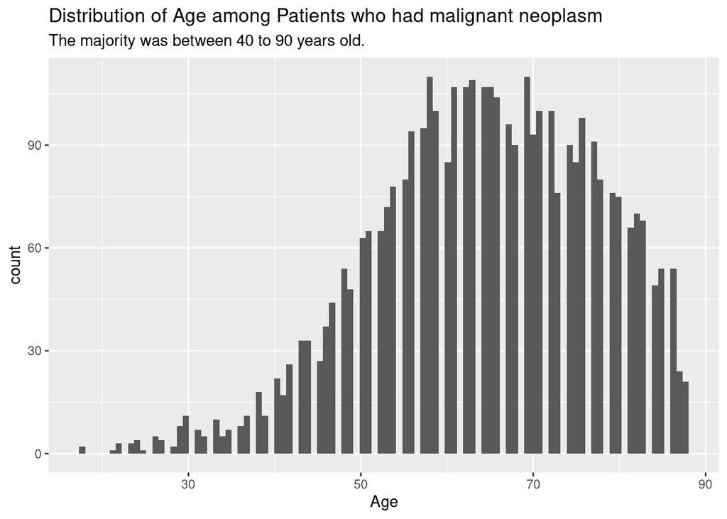

[figure not shown]

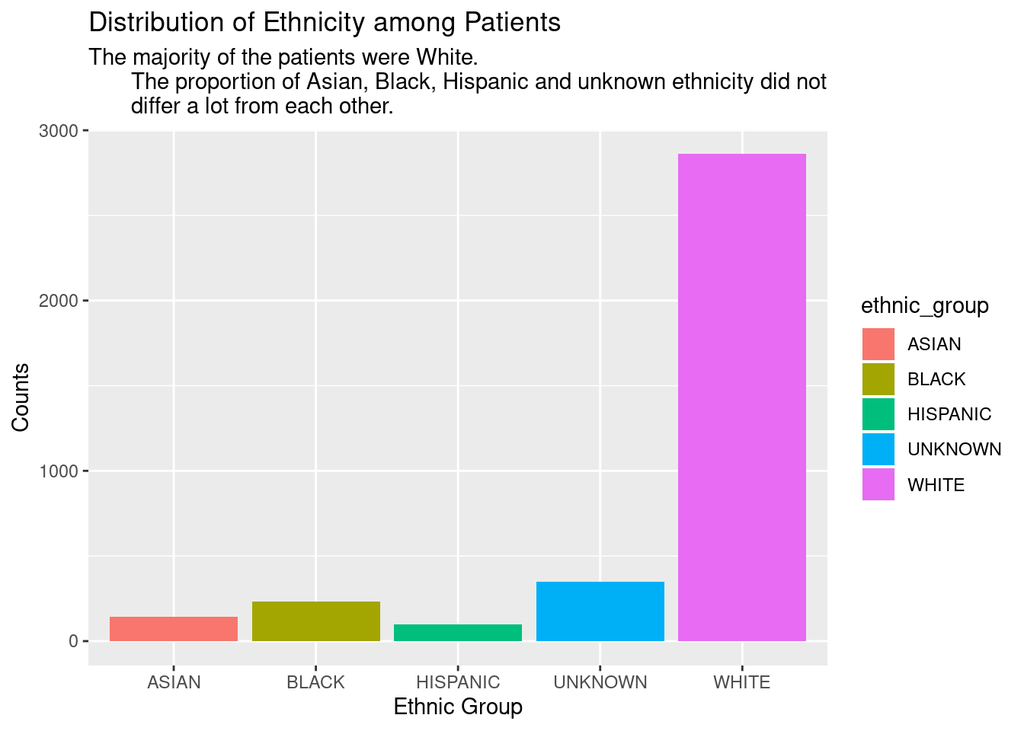

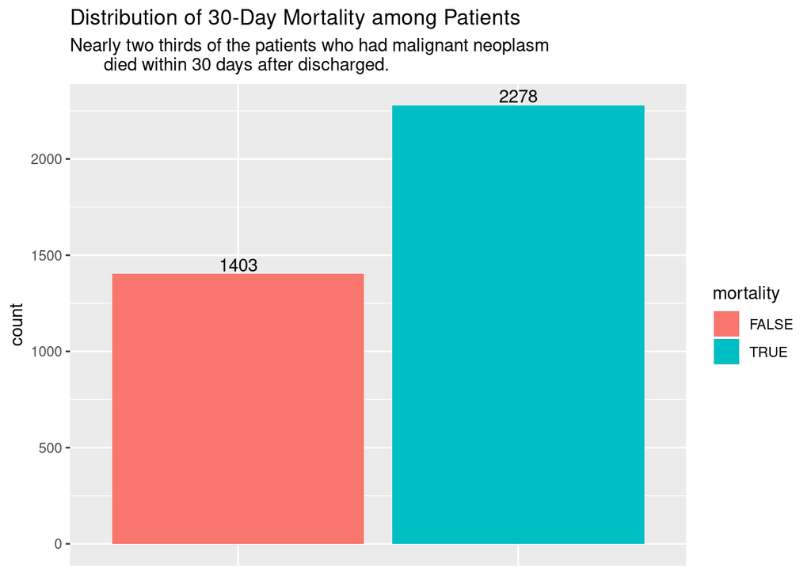

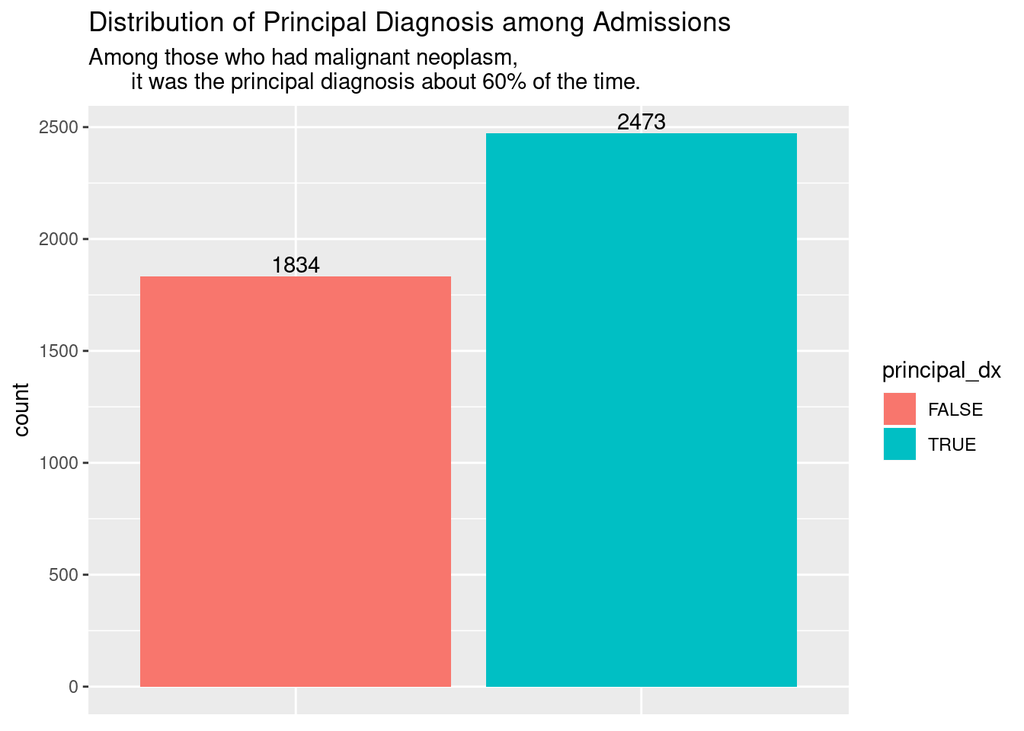

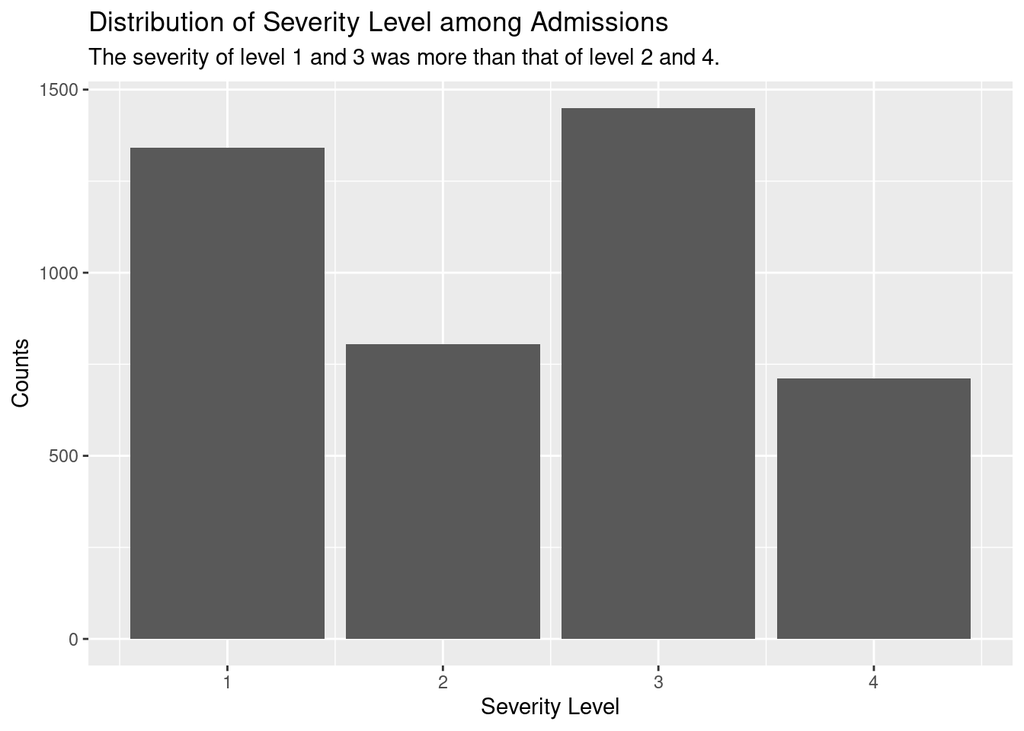

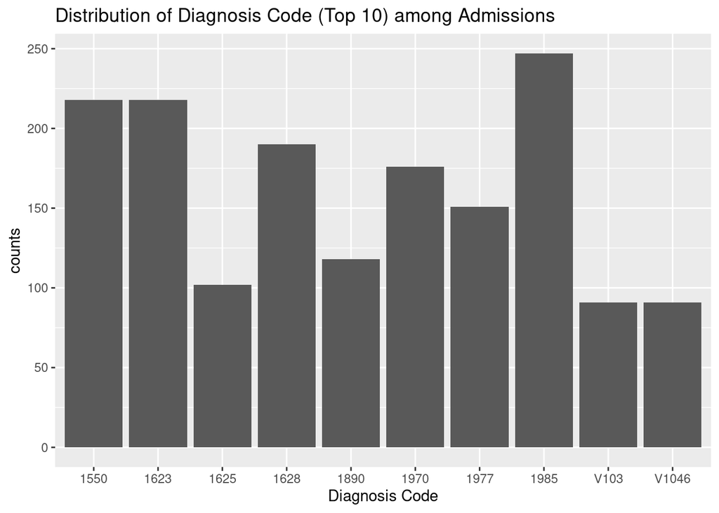

## Analytics

First, we convert the study cohort to a numeric matrix:

```r
study_admissions_n <- study_admissions
study_admissions_n$gender[study_admissions_n$gender == "M"] <- 0
study_admissions_n$gender[study_admissions_n$gender == "F"] <- 1
study_admissions_n$gender <- as.numeric(study_admissions_n$gender)
study_admissions_n$ethnic_group[study_admissions_n$ethnic_group == "WHITE"] <- 0
study_admissions_n$ethnic_group[study_admissions_n$ethnic_group == "BLACK"] <- 1
study_admissions_n$ethnic_group[study_admissions_n$ethnic_group == "HISPANIC"] <- 2
study_admissions_n$ethnic_group[study_admissions_n$ethnic_group == "ASIAN"] <- 3
study_admissions_n$ethnic_group[study_admissions_n$ethnic_group == "UNKNOWN"] <- 4
# some of the `icd9_code` contain character 'V',
# so we eliminate the character to avoid having NA
study_admissions_n$icd9_code <- as.numeric(gsub("[a-zA-Z ]", "",
                                                study_admissions_n$icd9_code))
study_admissions_n$ethnic_group <- as.numeric(study_admissions_n$ethnic_group)
study_admissions_n$principal_dx <- as.numeric(study_admissions_n$principal_dx)
study_admissions_n$mortality <- as.numeric(study_admissions_n$mortality)
study_admissions_n$icd9_code <- as.numeric(study_admissions_n$icd9_code)
head(study_admissions_n)
```

```
## # A tibble: 6 x 9
##   subject_id hadm_id   age mortality drg_severity icd9_code principal_dx gender
##        <int>   <int> <dbl>     <dbl>        <dbl>     <dbl>        <dbl>  <dbl>
## 1         11  194540    50         1            1      1913            1      1
## 2         41  101757    56         1            4      1917            1      0
## 3         84  120969    44         1            1      1919            1      1
## 4        103  130744    60         1            1      1983            1      1
## 5        113  109976    35         0            1      1915            1      0
## 6        115  114585    75         1            4      1940            1      1
## # … with 1 more variable: ethnic_group <dbl>
```

Let’s partition the study cohort into two independent sets, approximately 75% for training and 25% for testing:

```r
library(keras)
library(ISLR)
set.seed(123)
smp_siz = floor(0.75*nrow(collect(study_admissions_n)))
train_ind = sample(seq_len(nrow(collect(study_admissions_n))), size = smp_siz)
training = collect(study_admissions_n)[train_ind, ]
testing = collect(study_admissions_n)[-train_ind, ]
```

Then, we convert the x and y into matrix and encode y as binary class matrix. Our predictors (x) includes `age`, `gender`, `ethnic_group`, `principal_dx`, `icd9_code` and `drg_severity`; our dependent variable (y) is `mortality`:

```r
training %>%
  select(-mortality, -subject_id, -hadm_id) %>%
  as.matrix() %>%
  print() -> xtrain
training %>%
  select(mortality) %>%
  as.matrix() %>%
  to_categorical(2) %>%
  print() -> ytrain
testing %>%
  select(-mortality, -subject_id, -hadm_id) %>%
  as.matrix() %>%
  print() -> xtest
testing %>%
  select(mortality) %>%
  as.matrix() %>%
  to_categorical(2) %>%
  print() -> ytest
```

### Neural Network

Define a **sequential model** (a linear stack of layers) with 2 fully-connected hidden layers (256 and 128 neurons):

```r
model <- keras_model_sequential()
model %>%
  layer_dense(units = 256, activation = 'relu', input_shape = c(6)) %>%
  layer_dropout(rate = 0.4) %>%
  layer_dense(units = 128, activation = 'relu') %>%
  layer_dropout(rate = 0.3) %>%
  layer_dense(units = 2, activation = 'softmax')
summary(model)
```

```
## Model: "sequential"
## ________________________________________________________________________________
## Layer (type)                        Output Shape                    Param #
## ================================================================================
## dense (Dense)                       (None, 256)                     1792
## ________________________________________________________________________________
## dropout (Dropout)                   (None, 256)                     0
## ________________________________________________________________________________
## dense_1 (Dense)                     (None, 128)                     32896
## ________________________________________________________________________________
## dropout_1 (Dropout)                 (None, 128)                     0
## ________________________________________________________________________________
## dense_2 (Dense)                     (None, 2)                       258
## ================================================================================
## Total params: 34,946
## Trainable params: 34,946
## Non-trainable params: 0
## ________________________________________________________________________________
```

Compile the model with appropriate loss function, optimizer, and metrics:

```r
model %>% compile(
  loss = 'categorical_crossentropy',
  optimizer = optimizer_rmsprop(),
  metrics = c('accuracy')
)
```

Fit the model by using the train data:

```r
history <- model %>% fit(
  xtrain, ytrain,
  epochs = 30, batch_size = 128,
  validation_split = 0.2
)
```

Evaluate model performance on the test data:

```r
model %>% evaluate(xtest, ytest)
```

```
## $loss
## [1] 0.6509693
##
## $accuracy
## [1] 0.6610956
```

### Logistics Regression

We fit the same model using keras, since multinomial-logit is just an MLP with (1) one input layer with linear activation and (2) one output layer with softmax link function.

```r
library(keras)
mlogit <- keras_model_sequential()
mlogit %>%
#  layer_dense(units = 256, activation = 'linear', input_shape = c(784)) %>%
#  layer_dropout(rate = 0.4) %>%
  layer_dense(units = 2, activation = 'softmax', input_shape = c(6))
summary(mlogit)
```

```
## Model: "sequential_1"
## ________________________________________________________________________________
## Layer (type)                        Output Shape                    Param #
## ================================================================================
## dense_3 (Dense)                     (None, 2)                       14
## ================================================================================
## Total params: 14
## Trainable params: 14
## Non-trainable params: 0
## ________________________________________________________________________________
```

Compile the model with appropriate loss function, optimizer, and metrics:

```r
mlogit %>% compile(
  loss = 'categorical_crossentropy',
  optimizer = optimizer_rmsprop(),
  metrics = c('accuracy')
)
```

Fit the model by using the training data:

```r
mlogit_history <- mlogit %>% fit(
  xtrain, ytrain,
  epochs = 20, batch_size = 128,
  validation_split = 0.2
)
```

Evaluate model performance on the test data:

```r
mlogit %>% evaluate(xtest, ytest)
```

```
## $loss
## [1] 0.7282009
##
## $accuracy
## [1] 0.647168
```

Close the connection to the database:

```r
dbDisconnect(con)
```

```
## [1] TRUE
```

## Conclusion

Though the predictive accuracies of both approaches change each time we refit the model, neural network always perform better than logistic regression. In addition, it consistently has an accuracy over 0.65. Therefore, we conclude that the predictors we selected could attain a predictive accuracy over 65% on predicting the 30-day mortality rate induced by malignant neoplasm by using neural network. It means that based on the information of an independent patient, including `age`, `gender`, `ethnic_group`, `principal_dx`, `icd9_code` and `drg_severity`, we can predict whether this patient died or will die within 30 days after discharge, and the probability that this prediction is correct is above 65% by using neural network.